# **Elahe Khodaverdi - 810100132**

## **CA4**

In this assignment, we intend to predict the number of customer purchases for a store’s product using three methods. We first do this using linear regression, then with the gradient descent method, and finally, we use the Scikit-learn library.

First we need to import necessary libraries.

```python
import pandas
import copy
import numpy as np
import seaborn as sns
import matplotlib.pyplot as plt
import category_encoders as ce

from scipy import stats
from sklearn import preprocessing
from sklearn.model_selection import train_test_split
from sklearn.model_selection import StratifiedShuffleSplit
```

```python
first_dataframe = pandas.read_csv('marketing_campaign.csv')
target = 'NumPurchases'
```

## **Exploratory Data Analysis**

### 1. `info()` , `describe()`

```python
first_dataframe.describe()
```

|  | ID | Year_Birth | Income | Kidhome | Teenhome | Recency | MntCoffee | MntFruits | MntMeatProducts | MntFishProducts | MntSweetProducts | MntGoldProds | NumWebVisitsMonth | Complain | NumPurchases | UsedCampaignOffer |
| --- | --- | --- | --- | --- | --- | --- | --- | --- | --- | --- | --- | --- | --- | --- | --- | --- |
| count | 2240.000000 | 2240.000000 | 2017.000000 | 2240.000000 | 2240.000000 | 2240.000000 | 2035.000000 | 2240.000000 | 2240.000000 | 2240.000000 | 2240.000000 | 2227.000000 | 2040.000000 | 2240.000000 | 2240.000000 | 2240.000000 |
| mean | 5592.159821 | 1968.805804 | 52297.080317 | 0.437946 | 0.506250 | 49.109375 | 304.239312 | 26.302232 | 166.950000 | 37.525446 | 27.062946 | 43.847777 | 5.326961 | 0.009375 | 14.862054 | 0.271875 |
| std | 3246.662198 | 11.984069 | 25543.108215 | 0.563666 | 0.544538 | 28.962453 | 337.515534 | 39.773434 | 225.715373 | 54.628979 | 41.280498 | 51.897098 | 2.439349 | 0.096391 | 7.677173 | 0.445025 |
| min | 0.000000 | 1893.000000 | 2447.000000 | -5.000000 | 0.000000 | 0.000000 | 0.000000 | 0.000000 | 0.000000 | 0.000000 | 0.000000 | 0.000000 | 0.000000 | 0.000000 | 0.000000 | 0.000000 |
| 25% | 2828.250000 | 1959.000000 | 35340.000000 | 0.000000 | 0.000000 | 24.000000 | 23.000000 | 1.000000 | 16.000000 | 3.000000 | 1.000000 | 9.000000 | 3.000000 | 0.000000 | 8.000000 | 0.000000 |
| 50% | 5458.500000 | 1970.000000 | 51369.000000 | 0.000000 | 0.000000 | 49.000000 | 177.000000 | 8.000000 | 67.000000 | 12.000000 | 8.000000 | 24.000000 | 6.000000 | 0.000000 | 15.000000 | 0.000000 |
| 75% | 8427.750000 | 1977.000000 | 68316.000000 | 1.000000 | 1.000000 | 74.000000 | 505.000000 | 33.000000 | 232.000000 | 50.000000 | 33.000000 | 56.000000 | 7.000000 | 0.000000 | 21.000000 | 1.000000 |
| max | 11191.000000 | 1996.000000 | 666666.000000 | 2.000000 | 2.000000 | 99.000000 | 1493.000000 | 199.000000 | 1725.000000 | 259.000000 | 263.000000 | 362.000000 | 20.000000 | 1.000000 | 44.000000 | 1.000000 |

```python
first_dataframe.info()
```

```
<class 'pandas.core.frame.DataFrame'>
Index: 2240 entries, 0 to 2239
Data columns (total 19 columns):
 #   Column             Non-Null Count  Dtype
---  ------             --------------  -----
 0   ID                 2240 non-null   int64
 1   Year_Birth         2240 non-null   int64
 2   Education          2240 non-null   object
 3   Marital_Status     2240 non-null   object
 4   Income             2017 non-null   float64
 5   Kidhome            2240 non-null   int64
 6   Teenhome           2240 non-null   int64
 7   Dt_Customer        2240 non-null   object
 8   Recency            2240 non-null   int64
 9   MntCoffee          2035 non-null   float64
 10  MntFruits          2240 non-null   int64
 11  MntMeatProducts    2240 non-null   int64
 12  MntFishProducts    2240 non-null   int64
 13  MntSweetProducts   2240 non-null   int64
 14  MntGoldProds       2227 non-null   float64
 15  NumWebVisitsMonth  2040 non-null   float64
 16  Complain           2240 non-null   int64
 17  NumPurchases       2240 non-null   int64
 18  UsedCampaignOffer  2240 non-null   int64
dtypes: float64(4), int64(12), object(3)
memory usage: 350.0+ KB
```

```python
first_dataframe.tail()
```

|  | ID | Year_Birth | Education | Marital_Status | Income | Kidhome | Teenhome | Dt_Customer | Recency | MntCoffee | MntFruits | MntMeatProducts | MntFishProducts | MntSweetProducts | MntGoldProds | NumWebVisitsMonth | Complain | NumPurchases | UsedCampaignOffer |
| --- | --- | --- | --- | --- | --- | --- | --- | --- | --- | --- | --- | --- | --- | --- | --- | --- | --- | --- | --- |
| 2235 | 10870 | 1967 | Graduation | Married | 61223.0 | 0 | 1 | 13-06-2013 | 46 | 709.0 | 43 | 182 | 42 | 118 | 247.0 | 5.0 | 0 | 18 | 0 |
| 2236 | 4001 | 1946 | PhD | Together | 64014.0 | 2 | 1 | 10-06-2014 | 56 | 406.0 | 0 | 30 | 0 | 0 | 8.0 | 7.0 | 0 | 22 | 1 |
| 2237 | 7270 | 1981 | Graduation | Divorced | 56981.0 | 0 | 0 | 25-01-2014 | 91 | 908.0 | 48 | 217 | 32 | 12 | 24.0 | 6.0 | 0 | 19 | 1 |
| 2238 | 8235 | 1956 | Master | Together | 69245.0 | 0 | 1 | 24-01-2014 | 8 | 428.0 | 30 | 214 | 80 | 30 | 61.0 | NaN | 0 | 23 | 0 |
| 2239 | 9405 | 1954 | PhD | Married | 52869.0 | 1 | 1 | 15-10-2012 | 40 | 84.0 | 3 | 61 | 2 | 1 | 21.0 | 7.0 | 0 | 11 | 1 |

### 2. Missing values

```python
def missing_values(df):
    nan_values_count = df.isna().sum()
    nan_values_percent = nan_values_count / len(df)
    nan_values = pandas.concat([nan_values_count, nan_values_percent], axis=1, keys=['Missing', 'Percent'])
    return nan_values.sort_values(by='Missing', ascending=False)

missing_values(first_dataframe)
```

|  | Missing | Percent |
| --- | --- | --- |
| Income | 223 | 0.099554 |
| MntCoffee | 205 | 0.091518 |
| NumWebVisitsMonth | 200 | 0.089286 |
| MntGoldProds | 13 | 0.005804 |
| MntFruits | 0 | 0.000000 |
| NumPurchases | 0 | 0.000000 |
| Complain | 0 | 0.000000 |
| MntSweetProducts | 0 | 0.000000 |
| MntFishProducts | 0 | 0.000000 |
| MntMeatProducts | 0 | 0.000000 |
| ID | 0 | 0.000000 |
| Year_Birth | 0 | 0.000000 |
| Recency | 0 | 0.000000 |
| Dt_Customer | 0 | 0.000000 |
| Teenhome | 0 | 0.000000 |
| Kidhome | 0 | 0.000000 |
| Marital_Status | 0 | 0.000000 |
| Education | 0 | 0.000000 |
| UsedCampaignOffer | 0 | 0.000000 |

### 3. Plot Correlation

To plot the correlation, we first need to encode data of object type into numerical values

```python
cols_categories = {}
object_columns = first_dataframe.select_dtypes(include=['object']).columns
dataframe = copy.deepcopy(first_dataframe)
for col in first_dataframe.select_dtypes(include = object):
    col_categories = first_dataframe[col].astype("category").cat.categories
    cols_categories[col] = dict(zip(col_categories, range(len(col_categories))))
    dataframe[col] = first_dataframe[col].astype("category").dropna().cat.codes

cols_categories['Education']
```

```
{'2n Cycle': 0, 'Basic': 1, 'Graduation': 2, 'Master': 3, 'PhD': 4}
```

```python
dataframe.info()
```

```
<class 'pandas.core.frame.DataFrame'>
Index: 2240 entries, 0 to 2239
Data columns (total 19 columns):
 #   Column             Non-Null Count  Dtype
---  ------             --------------  -----
 0   ID                 2240 non-null   int64
 1   Year_Birth         2240 non-null   int64
 2   Education          2240 non-null   int8
 3   Marital_Status     2240 non-null   int8
 4   Income             2017 non-null   float64
 5   Kidhome            2240 non-null   int64
 6   Teenhome           2240 non-null   int64
 7   Dt_Customer        2240 non-null   int16
 8   Recency            2240 non-null   int64
 9   MntCoffee          2035 non-null   float64
 10  MntFruits          2240 non-null   int64
 11  MntMeatProducts    2240 non-null   int64
 12  MntFishProducts    2240 non-null   int64
 13  MntSweetProducts   2240 non-null   int64
 14  MntGoldProds       2227 non-null   float64
 15  NumWebVisitsMonth  2040 non-null   float64
 16  Complain           2240 non-null   int64
 17  NumPurchases       2240 non-null   int64
 18  UsedCampaignOffer  2240 non-null   int64
dtypes: float64(4), int16(1), int64(12), int8(2)
memory usage: 306.2 KB
```

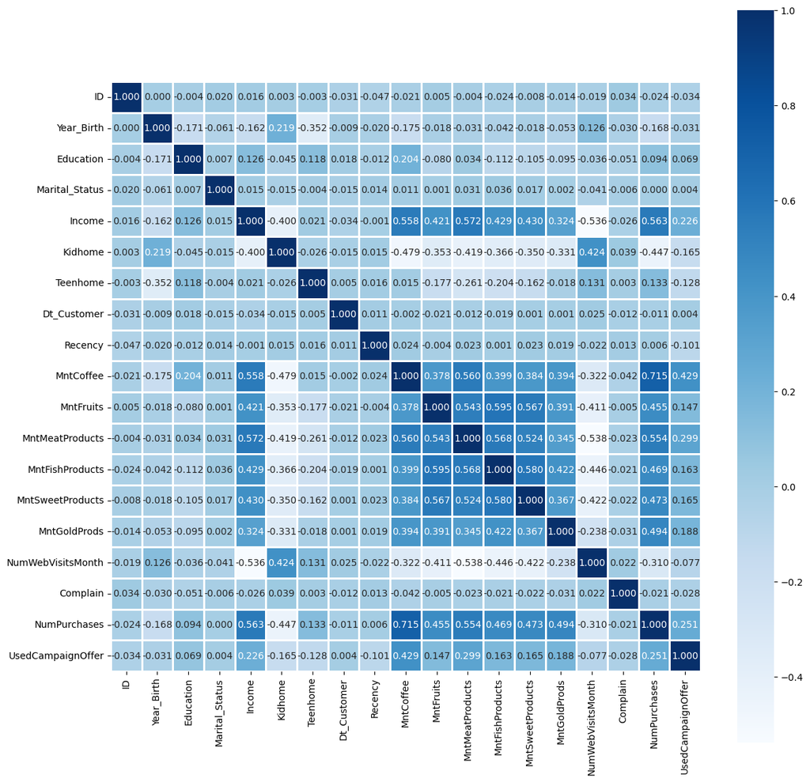

```python
corr = dataframe.corr()
plt.figure(figsize=(14,14))
sns.heatmap(corr, annot=True, fmt=".3f", cmap="Blues", linewidths=1, square=True)
plt.show()
```

```python
cur = dataframe.corr()[target].drop(target)
cur = cur[(cur >= 0.2) | (cur <= -0.2)].sort_values()
top_cur = cur.nlargest(6)
top_cur
```

```
MntCoffee           0.715164
Income              0.562603
MntMeatProducts     0.554229
MntGoldProds        0.493939
MntSweetProducts    0.472876
MntFishProducts     0.469454
Name: NumPurchases, dtype: float64
```

### 4. Unique Values Count

```python
dataframe.nunique()
```

```
ID                   2240
Year_Birth             59
Education               5
Marital_Status          8
Income               1810
Kidhome                 5
Teenhome                3
Dt_Customer           663
Recency               100
MntCoffee             747
MntFruits             158
MntMeatProducts       558
MntFishProducts       182
MntSweetProducts      177
MntGoldProds          212
NumWebVisitsMonth      15
Complain                2
NumPurchases           39
UsedCampaignOffer       2
dtype: int64
```

```python
def plot_unique_count(df, feature):
    counts = df[feature].value_counts()

    counts.plot(kind='bar')
    plt.title('Number of unique values for feature {feature}'.format(feature=feature))
    plt.xlabel('Unique Values')
    plt.ylabel('Count')
    plt.xticks([])
    plt.show()
```

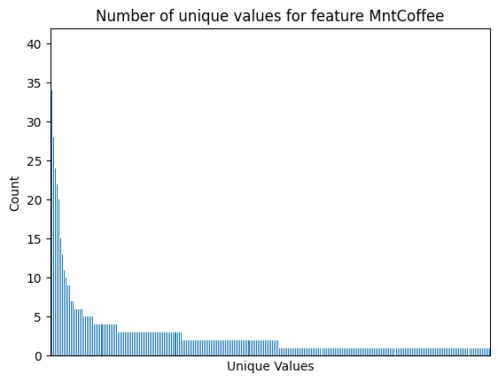

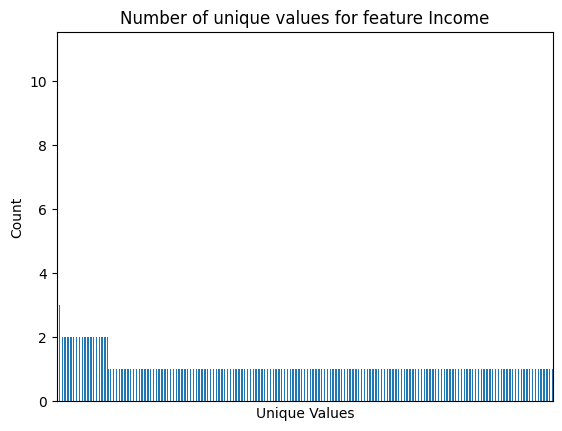

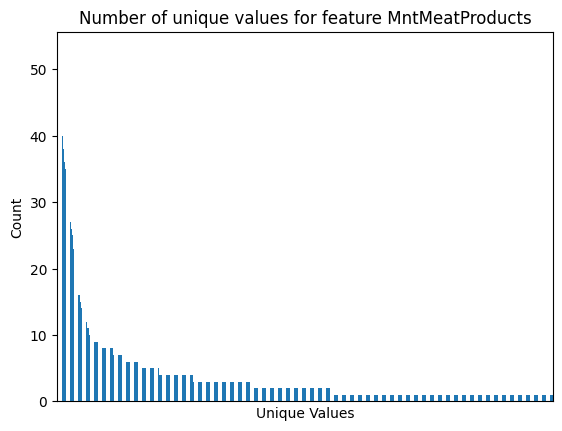

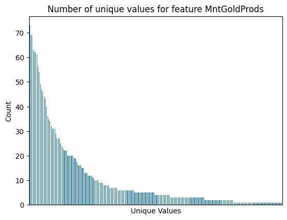

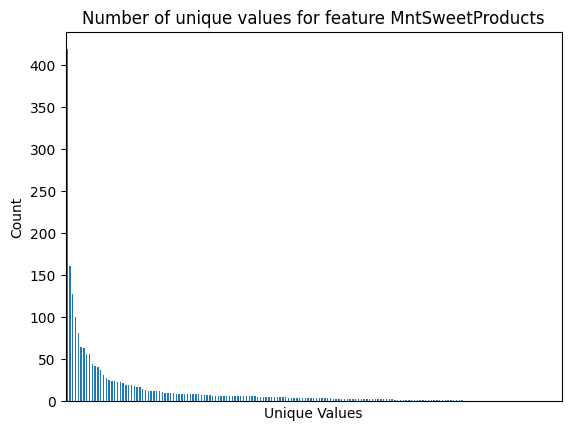

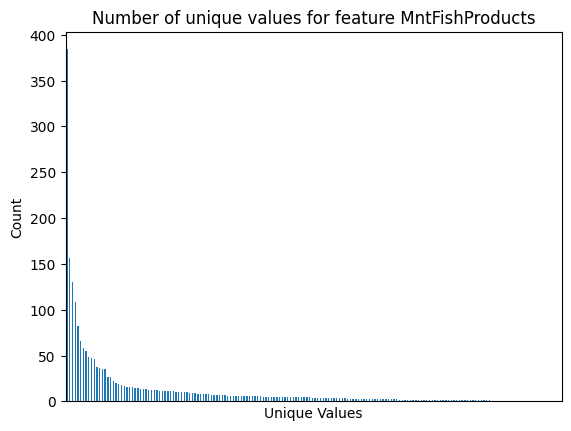

```python
dependents = top_cur.index
for feature in dependents:
    plot_unique_count(dataframe, feature)
```

### 5. Scatter and Hexbin Plots

```python
def scatter_plot(df, feature1, feature2):
    plt.figure(figsize=(10,6))
    sns.scatterplot(data=df, x=feature1, y=feature2)
    plt.title('Scatter plot of {feature1} vs {feature2}'.format(feature1=feature1, feature2=feature2))
    plt.show()

def hexbin_plot(df, feature1, feature2):
    plt.figure(figsize=(10,6))
    plt.hexbin(df[feature1], df[feature2], gridsize=30, cmap='Blues')
    cb = plt.colorbar(label='count in bin')
    plt.title('Hexbin plot of {feature1} vs {feature2}'.format(feature1=feature1, feature2=feature2))
    plt.show()
```

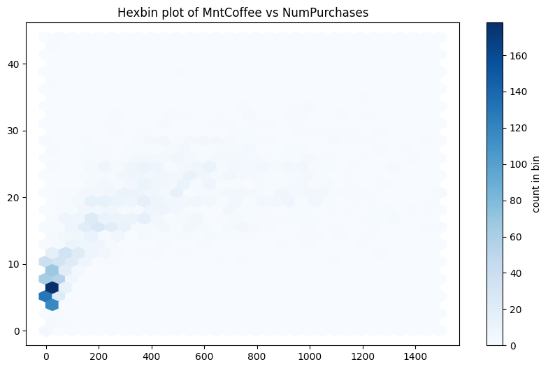

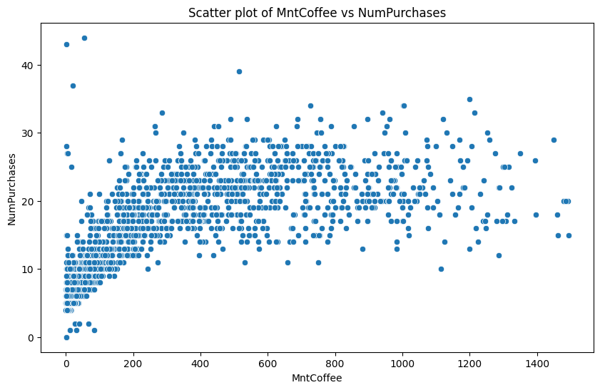

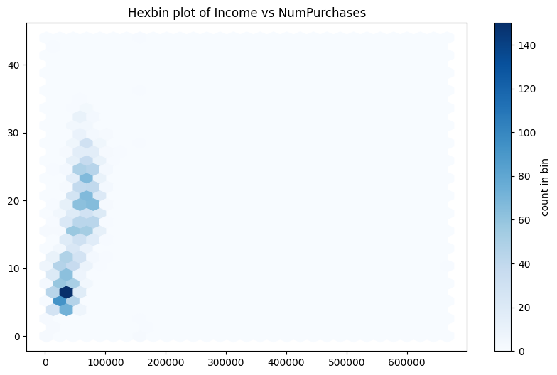

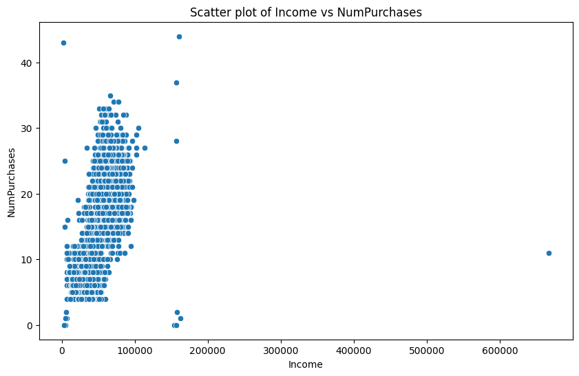

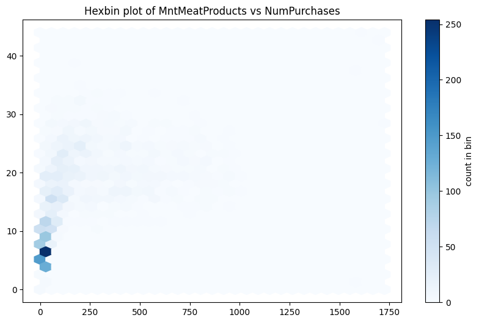

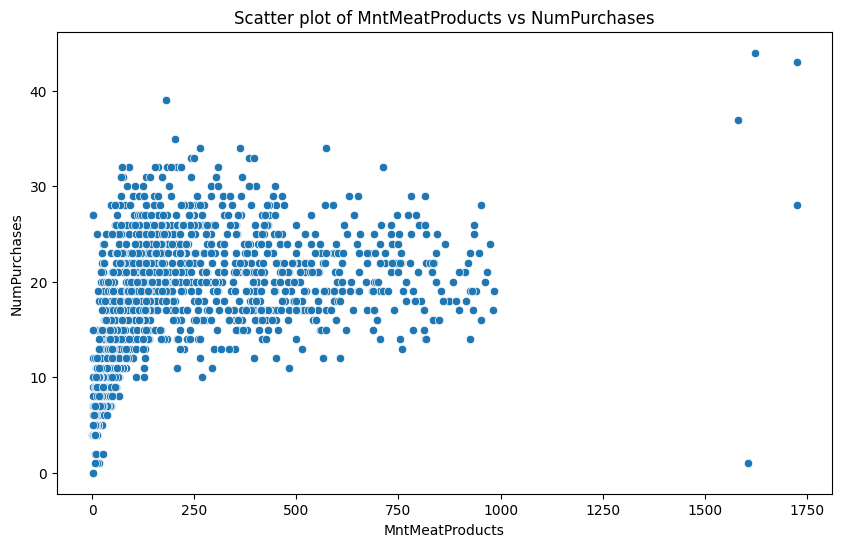

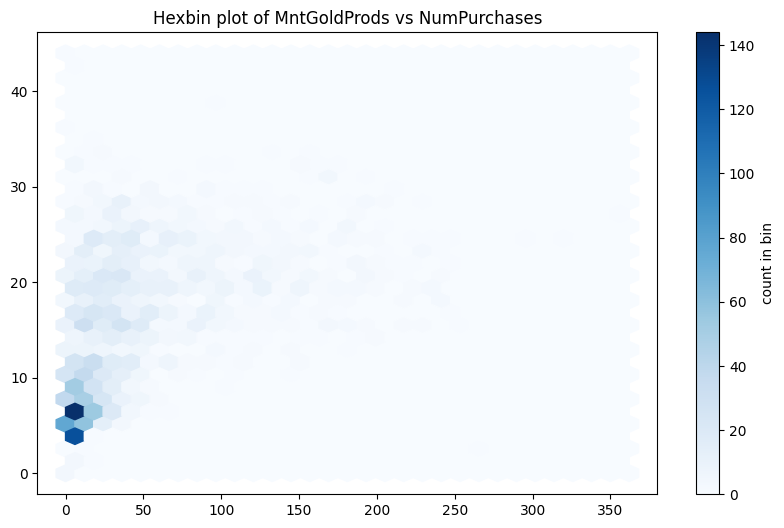

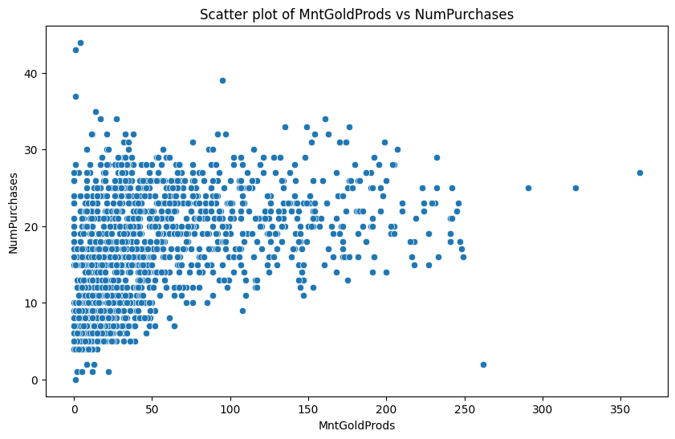

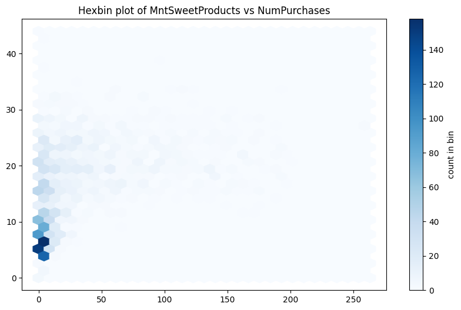

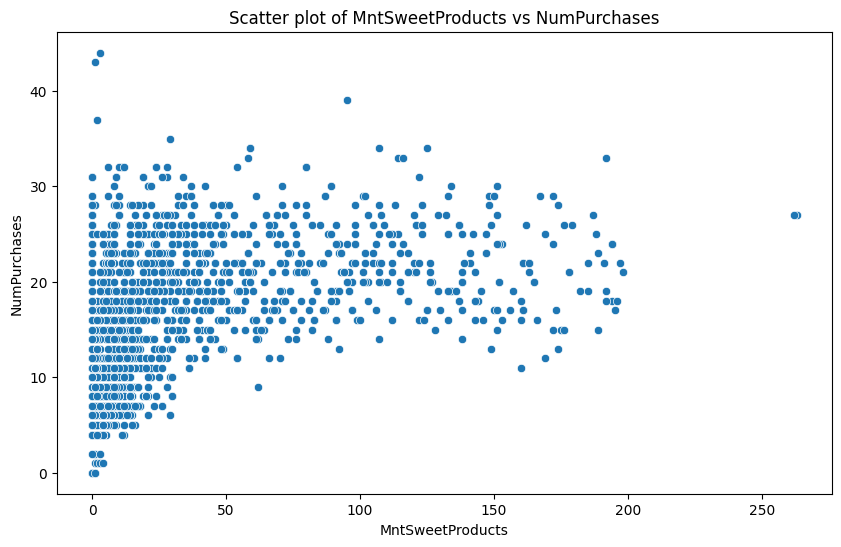

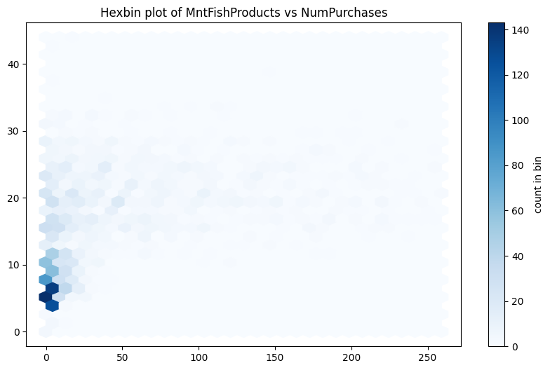

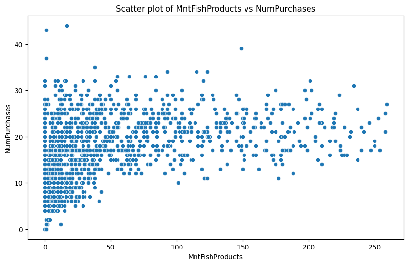

```python
for feature in dependents:
    hexbin_plot(dataframe, feature, target)
    scatter_plot(dataframe, feature, target)
```

### 6. Deleting Outliers

```python
def remove_outliers(df, columns, threshold=1.5):
    removed_outliers_num = {}
    new_df = copy.deepcopy(df)
    for col in columns:
        initial_length = len(new_df)
        Q1 = new_df[col].quantile(0.25)
        Q3 = new_df[col].quantile(0.75)
        IQR = Q3 - Q1
        new_df = new_df[~((new_df[col] < (Q1 - threshold * IQR)) | (new_df[col] > (Q3 + threshold * IQR)))]
        final_length = len(new_df)
        removed_outliers_num[col] = initial_length - final_length
    return new_df, removed_outliers_num

def impute_outliers_iqr(df, columns,  threshold=1.5):
    removed_outliers_num = {}
    new_df = copy.deepcopy(df)
    for col in columns:
        Q1 = new_df[col].quantile(0.25)
        Q3 = new_df[col].quantile(0.75)
        IQR = Q3 - Q1
        temp_df = new_df[((new_df[col] < (Q1 - threshold * IQR)) | (new_df[col] > (Q3 + threshold * IQR)))]
        new_df = new_df[~((new_df[col] < (Q1 - threshold * IQR)) | (new_df[col] > (Q3 + threshold * IQR)))]
        median = new_df[col].median()
        num_changes = len(temp_df)
        temp_df[col] = median
        new_df = pandas.concat([new_df,temp_df])
        removed_outliers_num[col] = num_changes
    return new_df, removed_outliers_num

def remove_outliers_z_score(df, columns, threshold=3):
    removed_outliers_num = {}
    new_df = copy.deepcopy(df)
    for col in columns:
        initial_length = len(new_df)
        z_scores = np.abs(stats.zscore(new_df[col]))
        filtered_entries = (z_scores < threshold)
        new_df = new_df[filtered_entries]
        final_length = len(new_df)
        removed_outliers_num[col] = initial_length - final_length
    return new_df, removed_outliers_num
```

```python
have_outliers = ['Income','MntMeatProducts','MntGoldProds','MntSweetProducts']
after_outlier_dataframe ,removed_outliers_num= remove_outliers(dataframe, have_outliers, threshold=5)
removed_outliers_num = pandas.DataFrame([removed_outliers_num])
removed_outliers_num
print( removed_outliers_num.sum(axis=1)[0],len(first_dataframe))
removed_outliers_num
```

```
13 2240
```

|  | Income | MntMeatProducts | MntGoldProds | MntSweetProducts |
| --- | --- | --- | --- | --- |
| 0 | 1 | 5 | 2 | 5 |

```python
after_outlier_dataframe ,removed_outliers_num= remove_outliers(after_outlier_dataframe,['MntGoldProds'], threshold=4)
removed_outliers_num = pandas.DataFrame([removed_outliers_num])
removed_outliers_num
```

|  | MntGoldProds |
| --- | --- |
| 0 | 7 |

```python
after_outlier_dataframe ,removed_outliers_num= remove_outliers(after_outlier_dataframe,['Income'], threshold=2.5)
removed_outliers_num = pandas.DataFrame([removed_outliers_num])
removed_outliers_num
```

|  | Income |
| --- | --- |
| 0 | 4 |

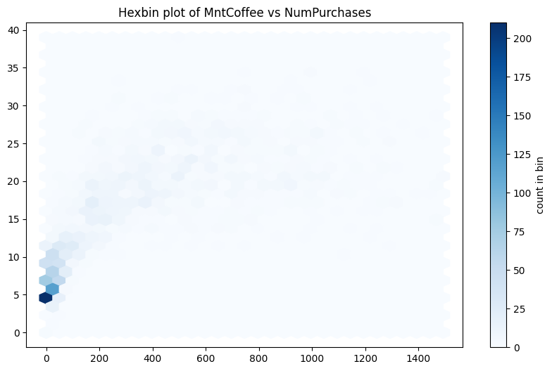

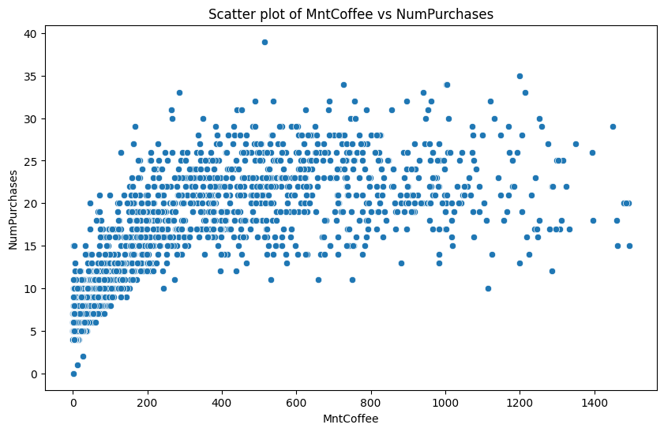

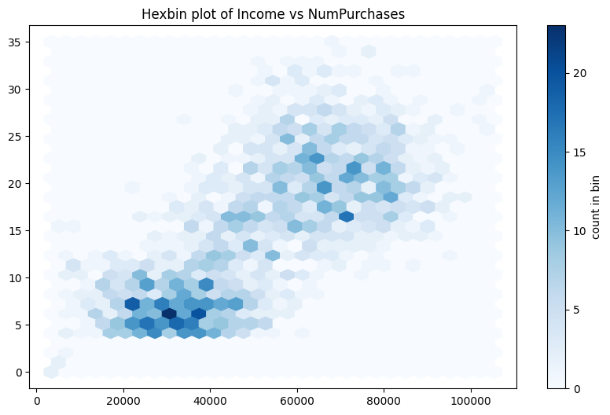

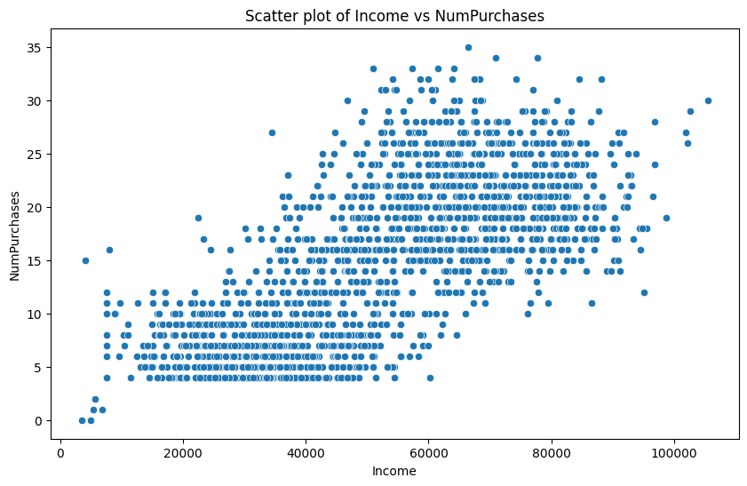

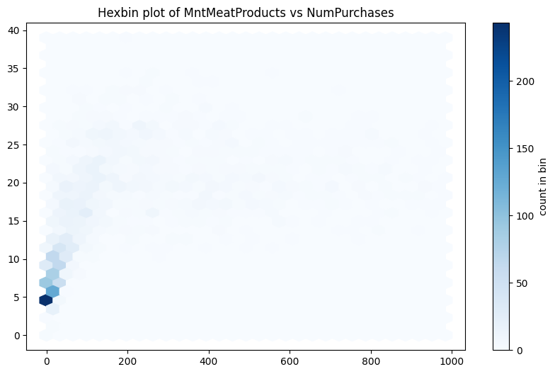

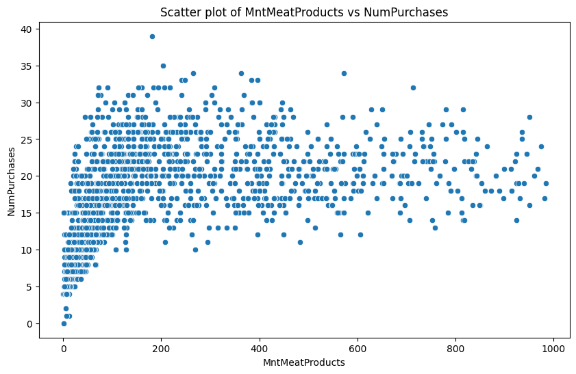

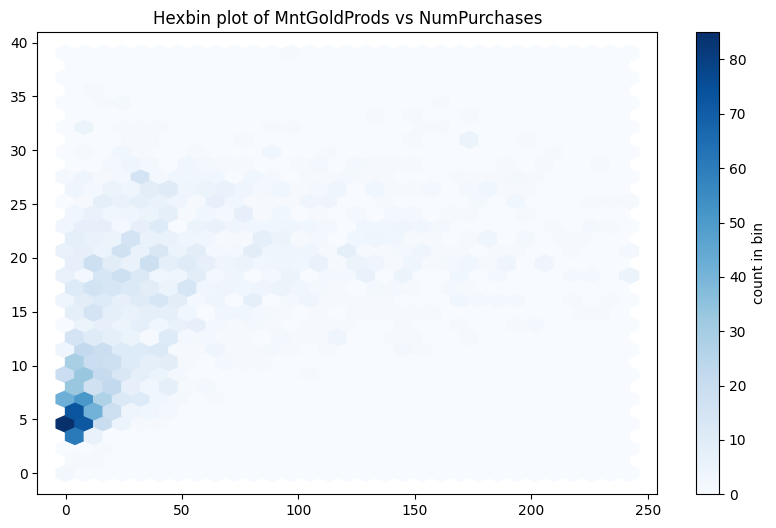

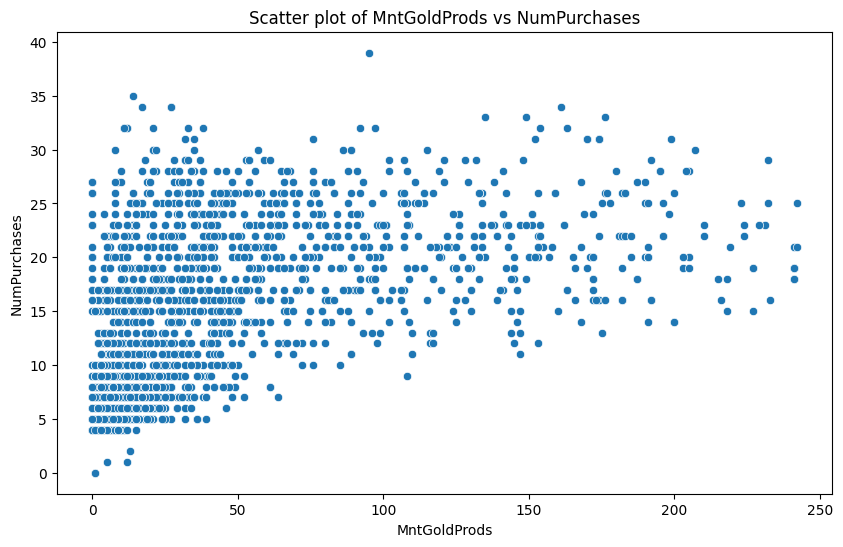

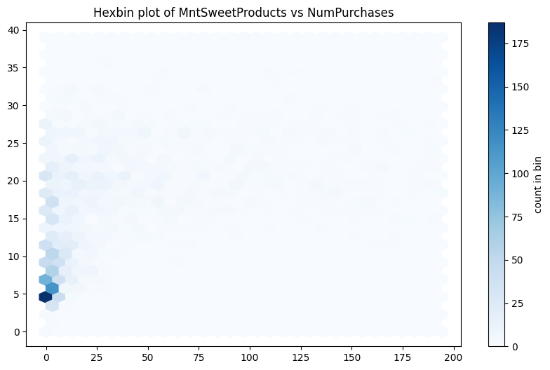

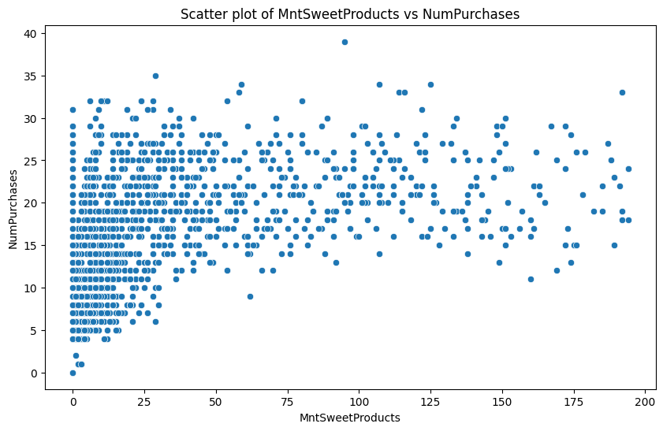

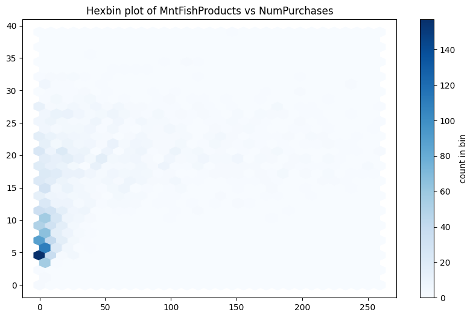

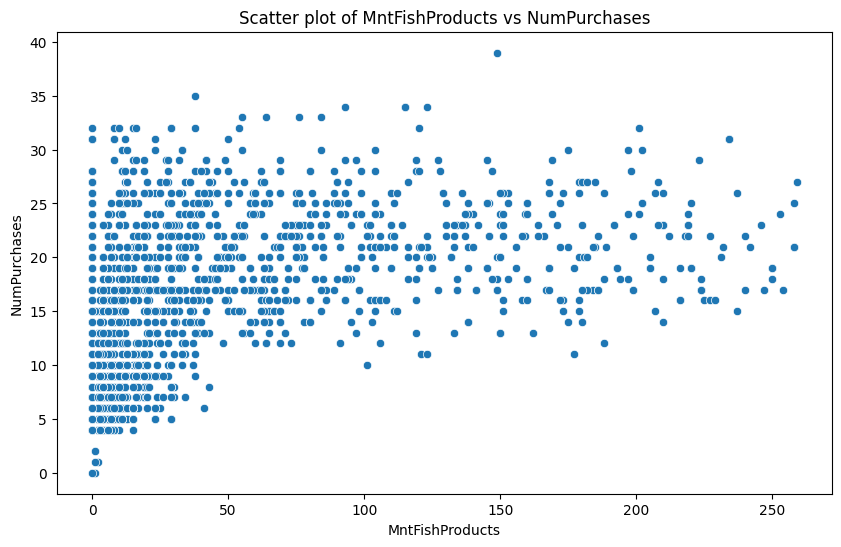

```python
for feature in dependents:
    hexbin_plot(after_outlier_dataframe, feature, target)
    scatter_plot(after_outlier_dataframe, feature, target)
```

```python
print(len(after_outlier_dataframe)/ len(first_dataframe))
```

```
0.9892857142857143
```

```python
dataframe = after_outlier_dataframe
```

## **Preprocessing Data**

### 7. Missing values

We have two primary way in solving missing values problem:

### 8. Solve Missing Values Problem

As we saw previously in question 2 we have this :

```python
missing_values(dataframe)
```

|  | Missing | Percent |
| --- | --- | --- |
| Income | 219 | 0.098827 |
| MntCoffee | 204 | 0.092058 |
| NumWebVisitsMonth | 198 | 0.089350 |
| MntGoldProds | 12 | 0.005415 |
| MntFruits | 0 | 0.000000 |
| NumPurchases | 0 | 0.000000 |
| Complain | 0 | 0.000000 |
| MntSweetProducts | 0 | 0.000000 |
| MntFishProducts | 0 | 0.000000 |
| MntMeatProducts | 0 | 0.000000 |
| ID | 0 | 0.000000 |
| Year_Birth | 0 | 0.000000 |
| Recency | 0 | 0.000000 |
| Dt_Customer | 0 | 0.000000 |
| Teenhome | 0 | 0.000000 |
| Kidhome | 0 | 0.000000 |
| Marital_Status | 0 | 0.000000 |
| Education | 0 | 0.000000 |
| UsedCampaignOffer | 0 | 0.000000 |

Based on the results, the features `Income`, `MntCoffee`, `NumWebVisitsMonth`, and `MntGoldProds` have missing values, with `Income` having the most. We use the "Filling with Medain" method to fill the missing values for these features.

```python
dataframe.fillna(dataframe.median(), inplace=True)
missing_values(dataframe)
```

|  | Missing | Percent |
| --- | --- | --- |
| ID | 0 | 0.0 |
| MntFruits | 0 | 0.0 |
| NumPurchases | 0 | 0.0 |
| Complain | 0 | 0.0 |
| NumWebVisitsMonth | 0 | 0.0 |
| MntGoldProds | 0 | 0.0 |
| MntSweetProducts | 0 | 0.0 |
| MntFishProducts | 0 | 0.0 |
| MntMeatProducts | 0 | 0.0 |
| MntCoffee | 0 | 0.0 |
| Year_Birth | 0 | 0.0 |
| Recency | 0 | 0.0 |
| Dt_Customer | 0 | 0.0 |
| Teenhome | 0 | 0.0 |
| Kidhome | 0 | 0.0 |
| Income | 0 | 0.0 |
| Marital_Status | 0 | 0.0 |
| Education | 0 | 0.0 |
| UsedCampaignOffer | 0 | 0.0 |

### 9. Nomalizing and Standardizing

Standardizing and normalizing values for data in machine learning are important techniques that can help to improve the performance and accuracy of various models. They involve transforming the data to make it more suitable for modeling, by reducing the impact of outliers, scaling the features to a common range, and ensuring that the data is on the same scale.

- **Standardization** is useful when you want to ensure zero mean and unit standard deviation for your features. This can help to make your data more comparable and reduce the effect of outliers. Standardization is also helpful when your data follows a Gaussian (bell curve) distribution or when you are using algorithms that are sensitive to the scale of the features, such as gradient descent based algorithms.
- **Normalization** is useful when you want to scale your features to a range between 0 and 1 or -1 and 1. This can help to make your data more suitable for algorithms that do not assume a specific distribution, such as k-nearest neighbors and artificial neural networks. Normalization is also helpful when you have features that have different scales or units of measurement.

```python
def normalize_dataframe(df, exceptions=[]):
    min_max_scaler = preprocessing.MinMaxScaler()
    for col in df.columns:
        if col not in exceptions:
            df[col] = min_max_scaler.fit_transform(df[[col]])
    return df

def standardize_dataframe(df, exceptions=[]):
    scaler = preprocessing.StandardScaler()
    for col in df.columns:
        if col not in exceptions:
            df[col] = scaler.fit_transform(df[[col]])
    return df
```

Given that we have outlier data among our data, it might be better to standardize the data.

### 10. Categorical Variables

- **Label encoding:** Assigns a unique integer value to each category. It’s simple and easy to implement, but it doesn’t preserve the order or hierarchy of the categories and may introduce sparsity or multicollinearity issues.
- **One-hot encoding:** Creates a binary vector for each category, where only one element is 1 and the rest are 0. It preserves the order and hierarchy of the categories, but it increases the dimensionality of the data significantly.
- **Ordinal encoding:** Assigns a numerical value to each category based on its rank or order. It captures the meaningful relationship between categories that have an inherent order or ranking.
- **Binary encoding:** Combines label encoding and one-hot encoding by converting each integer value into a binary number and creating binary features for each bit in the binary representation. It reduces the dimensionality of the data compared to one-hot encoding.
- **Frequency encoding:** Replaces each category with its frequency or count in the dataset. It’s useful when there are many categories in the dataset but they are not very different from each other in terms of their distribution or importance.

```python
def one_hot_encode(df, column):
    return pandas.get_dummies(df, columns=[column])

def label_encode(df, column):
    le = preprocessing.LabelEncoder()
    dataframe = copy.deepcopy(df)
    dataframe[column] = le.fit_transform(dataframe[column])
    return dataframe

def ordinal_encode(df, column):
    oe = preprocessing.OrdinalEncoder()
    dataframe = copy.deepcopy(df)
    dataframe[column] = oe.fit_transform(dataframe[[column]])
    return dataframe

def binary_encode(df, column):
    be = ce.BinaryEncoder(cols=[column])
    return be.fit_transform(df)

def frequency_encode(df, column):
    fe = df.groupby(column).size()/len(df)
    dataframe = copy.deepcopy(df)
    dataframe.loc[:, column + "_freq_encode"] = dataframe[column].map(fe)
    return df
```

### 11. Deleting Columns

Yes, we can remove some columns that are shown in the correlation plot to have no specific correlation with other features, such as columns `Complain`, `Marital_Status`, `Dt_Customer` and `Recency`.

```python
dataframe_dc = dataframe.drop(columns=['Complain', 'Marital_Status', 'Dt_Customer' , 'Recency'])
excp = list(object_columns)
excp += [target]
print(excp)
dataframe_dc = normalize_dataframe(dataframe_dc, exceptions=excp)
dataframe_dc = standardize_dataframe(dataframe_dc, exceptions= excp)
dataframe_dc
```

```
['Education', 'Marital_Status', 'Dt_Customer', 'NumPurchases']
```

|  | ID | Year_Birth | Education | Income | Kidhome | Teenhome | MntCoffee | MntFruits | MntMeatProducts | MntFishProducts | MntSweetProducts | MntGoldProds | NumWebVisitsMonth | NumPurchases | UsedCampaignOffer |
| --- | --- | --- | --- | --- | --- | --- | --- | --- | --- | --- | --- | --- | --- | --- | --- |
| 0 | -0.017821 | -0.983215 | 2 | 0.338778 | -0.780226 | -0.934007 | 1.051874 | 1.558269 | 1.788498 | 2.460062 | 1.534248 | 0.905136 | 0.253625 | 25 | 1.629959 |
| 1 | -1.049758 | -1.233671 | 2 | -0.265741 | 0.991271 | 0.904145 | -0.354098 | -0.636962 | -0.734586 | -0.651607 | -0.638878 | -0.742884 | -0.181048 | 6 | -0.613512 |
| 2 | -0.443842 | -0.315331 | 2 | 1.029459 | -0.780226 | -0.934007 | -0.354098 | 0.574200 | -0.169228 | 1.343522 | -0.139309 | -0.019363 | 0.253625 | 21 | -0.613512 |
| 3 | 0.184870 | 1.270893 | 2 | -1.275392 | 0.991271 | -0.934007 | -0.872087 | -0.561265 | -0.669173 | -0.505175 | -0.588922 | -0.762982 | 0.253625 | 8 | -0.613512 |
| 4 | -0.079429 | 1.020437 | 4 | 0.346723 | 0.991271 | -0.934007 | -0.372597 | 0.422804 | -0.211280 | 0.153766 | 0.010562 | -0.562004 | -0.181048 | 19 | -0.613512 |
| ... | ... | ... | ... | ... | ... | ... | ... | ... | ... | ... | ... | ... | ... | ... | ... |
| 2234 | 0.859479 | 0.436038 | 2 | -0.019864 | 0.991271 | -0.934007 | -0.896754 | -0.586497 | -0.729914 | -0.578391 | -0.613900 | -0.682591 | 0.688298 | 4 | -0.613512 |
| 2236 | -0.486967 | -1.901555 | 4 | 0.639961 | 2.762767 | 0.904145 | 0.345805 | -0.662195 | -0.622449 | -0.688215 | -0.663857 | -0.702689 | 0.688298 | 22 | 1.629959 |
| 2237 | 0.520018 | 1.020437 | 2 | 0.279474 | -0.780226 | -0.934007 | 1.893608 | 0.548967 | 0.251286 | -0.102489 | -0.364115 | -0.381124 | 0.253625 | 19 | 1.629959 |
| 2238 | 0.817277 | -1.066700 | 3 | 0.908084 | -0.780226 | 0.904145 | 0.413637 | 0.094781 | 0.237269 | 0.776100 | 0.085497 | 0.362495 | 0.253625 | 23 | -0.613512 |
| 2239 | 1.177685 | -1.233671 | 4 | 0.068708 | 0.991271 | 0.904145 | -0.647008 | -0.586497 | -0.477605 | -0.651607 | -0.638878 | -0.441417 | 0.688298 | 11 | 1.629959 |

2216 rows × 15 columns

### 12. Train and Test

The ratio of the division between the training and test sets in machine learning depends on various factors, such as the size of the dataset, the complexity of the model, and the desired level of accuracy. There is no definitive rule for choosing the optimal ratio, but some common values are 80:20, 75:25, and 70:30.

There are different methods for dividing and creating these two categories of data. One method is to use a random split, where each data point has an equal chance of being assigned to either the training or test set. This method is simple and fast, but it may not be representative of the true distribution of the data. Another method is to use a stratified split, where each class or category of data has a fixed proportion in both sets. This method ensures that the training and test sets have similar characteristics and do not introduce bias in the model evaluation. A third method is to use a cross-validation technique, where multiple subsets of data are used to train and test different models. This method allows for more accurate estimation of the model performance and reduces overfitting.

```python
def random_split(X_df, Y_df, test_size=0.2, random_state=42):
    X_train, X_test, Y_train, Y_test= train_test_split(X_df, Y_df, test_size=test_size, random_state=random_state)
    return  X_train, X_test, Y_train, Y_test

def stratified_split(df, target, test_size=0.2, random_state=42):
    sss = StratifiedShuffleSplit(n_splits=1, test_size=test_size, random_state=random_state)
    for train_index, test_index in sss.split(df, df[target]):
        train_df, test_df = df.iloc[train_index], df.iloc[test_index]
    return train_df, test_df
```

```python
X_df = dataframe_dc.drop(target, axis=1)
Y_df = dataframe_dc[target]
X_train, X_test, Y_train, Y_test = random_split(X_df, Y_df)
print('Train Data: {i} '.format(i = len(X_train)))
print('Test Data: {i} '.format(i = len(X_test)))
```

```
Train Data: 1772
Test Data: 444
```

### 13. Validation

In some cases, a third category of data, known as validation data, is utilized. In this scenario, the primary dataset is partitioned into three sections: training, validation, and testing. These sections typically comprise approximately 70%, 15%, and 15% of the data, respectively.

The validation data serves as a preliminary testing ground for the trained model prior to the application of the testing data. This stage facilitates the fine-tuning of the classifier’s hyperparameters.

### 14. K-fold Cross Validation

As i saw in previous question : *A third method is to use a cross-validation technique, where multiple subsets of data are used to train and test different models. This method allows for more accurate estimation of the model performance and reduces overfitting.*

## **Learning and Evaluation**

#### **Linear Regression**

Main form of simple linear regression function: $$f(x) = \alpha x + \beta$$

- step 1: Compute RSS of the training data

$$ RSS = \Sigma (y_i - (\hat{\beta} + \hat{\alpha} * x_i) )^2 $$

- step 2: Compute the derivatives of the RSS function in terms of $\alpha$ and $\beta$, and set them equal to 0 to find the desired parameters

$$ \frac{\partial RSS}{\partial \beta} = \Sigma (-f(x_i) + \hat{\beta} + \hat{\alpha} * x_i) = 0$$ $$ \to \beta = \hat{y} - \hat{\alpha} \hat{x} \to (1)$$

$$ \frac{\partial RSS}{\partial \alpha} = \Sigma (-2 x_i y_i + 2 \hat{\beta} x_i + 2\hat{\alpha} x_i ^ 2) = 0 \to (2)$$

$$ (1) , (2) \to \hat{\alpha} = \frac{\Sigma{(x_i - \hat{x})(y_i - \hat{y})}}{\Sigma{(x_i - \hat{x})^2}} $$ $$ \hat{\beta} = y - \hat{a} x$$

Based on the above formula, implement the function below to compute the parameters of a simple linear regression

```python
def simple_linear_regression(input_feature, output):
    mean_x = sum(input_feature) / len(input_feature)
    mean_y = sum(output) / len(output)

    numerator = sum([xi*yi for xi,yi in zip(input_feature, output)]) - len(input_feature)*mean_x*mean_y
    denominator = sum([xi**2 for xi in input_feature]) - len(input_feature)*mean_x**2

    slope = numerator / denominator
    bias = mean_y - (slope*mean_x)

    return bias, slope
```

Now complete this `get_regression_predictions(...)` function to predict the value of given data based on the calculated intercept and slope

```python
def get_regression_predictions(input_feature, bias, slope):
    predicted_values = [slope * feature + bias for feature in input_feature]
    return predicted_values
```

```python
def plot_real_vs_predictions(test_input, real, predicted_values, feature):
    plt.figure(figsize=(6, 4))
    plt.scatter(test_input, real, label="Actual Data")
    plt.plot(test_input, predicted_values, color='red', label="Regression Line")
    plt.title(f"Regression Line for {feature}")
    plt.xlabel(feature)
    plt.ylabel(target)
    plt.legend()
    plt.show()
```

Now that we have a model and can make predictions, let's evaluate our model using Root Mean Square Error (RMSE). RMSE is the square root of the mean of the squared differences between the residuals, and the residuals is just a fancy word for the difference between the predicted output and the true output.

Complete the following function to compute the RSME of a simple linear regression model given the input_feature, output, intercept and slope:

```python
def get_root_mean_square_error(predicted_values, outputs):
    squared_diffs = [(predicted - actual)**2 for predicted, actual in zip(predicted_values, outputs)]
    mean_squared_diff = sum(squared_diffs) / len(squared_diffs)
    rmse = mean_squared_diff**0.5
    return rmse
```

The RMSE has no bound, thus it becomes challenging to determine whether a particular RMSE value is considered good or bad without any reference point. Instead, we use R2 score. The R2 score is calculated by comparing the sum of the squared differences between the actual and predicted values of the dependent variable to the total sum of squared differences between the actual and mean values of the dependent variable. The R2 score is formulated as below:

$$R^2 = 1 - \frac{SSres}{SStot} = 1 - \frac{\sum_{i=1}^{n} (y_{i,true} - y_{i,pred})^2}{\sum_{i=1}^{n} (y_{i,true} - \bar{y}_{true})^2} $$

Complete the following function to calculate the R2 score of a given input_feature, output, bias, and slope:

```python
def get_r2_score(predicted_values, outputs):
    mean_outputs = outputs.mean()
    SS_tot = sum([(output - mean_outputs)**2 for output in outputs])
    SS_res = sum([(output - predicted)**2 for output, predicted in zip(outputs, predicted_values)])
    r2_score = 1 - (SS_res / SS_tot)
    return r2_score
```

##### 15.

As stated in the description, we are approximating the best linear line that we can apply to the data. The best line is the one that has the least error. We first consider a function for its error and say that this function is equal to its minimum value at a point where its derivative is zero. Therefore, we take the derivative of it and set it equal to zero. According to this assumption, by taking the derivative with respect to two variables, we can obtain two equations. Since we also have two unknown variables, we can find the variables with the help of the equations.

Now calculate the fitness of the model. Remember to provide explanation for the outputs in your code!

```python
designated_feature_list = dependents
predicted_values_train_p1 = {}
predicted_values_test_p1 = {}
r2_score_train_p1 ={}
r2_score_test_p1 ={}
rmse_train_p1 ={}
rmse_test_p1 ={}
```